# Lecture 04: The `ggplot` library

### 1.2.0.7 Most layers will inherit from default `aes()` unless explicitly specified

When setting the `aes()` parameter there are generally three ways to do this in order of inheritance

1. `ggplot(data = ... , mapping = (aes(x = ..., y = ..., colour = ...)))`
1. `(aes(x = ..., y = ..., colour = ...))`
1. `geom_*(aes(x = ..., y = ..., colour = ...))`

This means that colour can be specified using `geom_point(aes())` since it is a description of the points being plotted. When building a plot, using this command will supercede the plot's default mappings (if any were created and inherited). By placing version **2** into our code, at the beginning of our plot, we are essentially overriding the default mappings, which are nothing. I prefer to write the code this way for easier reading but method **1** is the more formal way of setting a default mapping to your plot.

It is *rare* that you might use **3** but not impossible. Especially when layering multiple geom_*() objects, you may find that you want them coloured in one way, but shaped or sized based on a different factor. Setting the default mappings at the start, take away having to input this information into each new layer of your ggplot object.

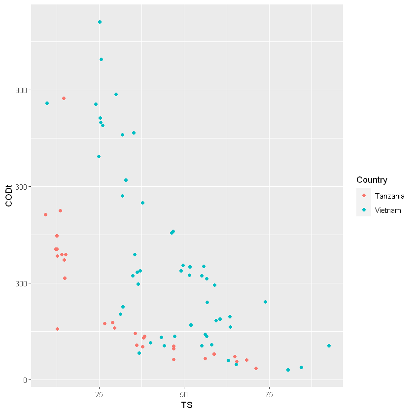

```r
#is equivalent in final output to but subsequent layers won't inherit this! compare the consequences
ggplot(metadata) +
    aes(x = TS, y = CODt) +
    geom_point(aes(colour = Country))
# What happens if we add a geom_line()?
```

### 1.2.0.8 Altering the scale of our axes with `scale_y_*()`

Some of our data points seem to be crushed near the x-axis. We can **scale** the y-axis to fix this. There are a number of ways to specify how the axes of our graph can be scaled. This is usually accomplished through the commands

`scale_y_*()` and `scale_x_*()` where * denotes a number of options in R including

- `discrete`
- `continuous`
- `log10`

Within these commands we can further specify the axis name, limits (start and end), breaks (tick mark locations), labels for each break, and axis (not data) transformations. In this case, lets keep it simple and log-transform our y-axis.

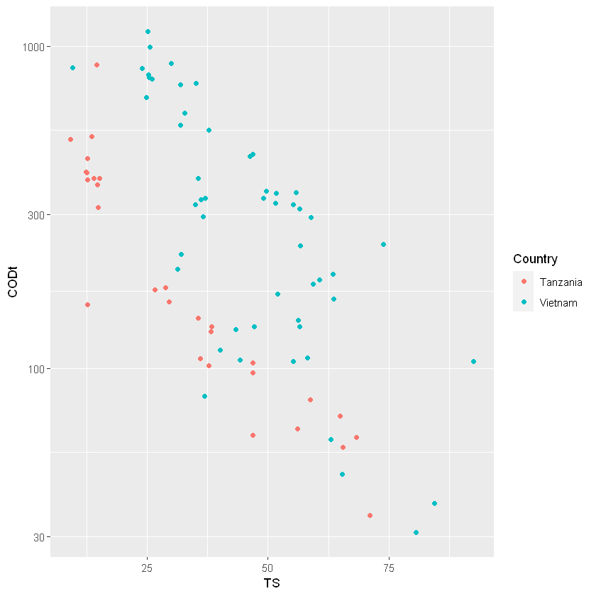

```r
# Convert the y-axis to a log10 scale
ggplot(metadata) +
    aes(x = TS, y = CODt, colour = Country) +
    geom_point() +
    scale_y_log10()
```

### 1.2.0.9 Altering the scale of our axes directly in `aes()`

Keep in mind that scaling does not change the data, but rather the representation of the data. The y-axis has been scaled. This is different than taking the log10 of the y data.

Can we transform our data directly? Yes, by manipulating the data in our specification of the y-axis data itself in our `aes()` call but take a close look at the resulting y-axis!

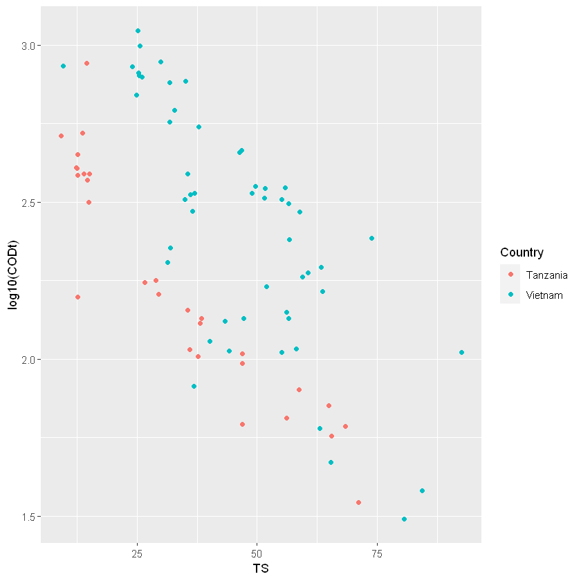

```r
# Update the y-axis aesthetic to scale the data directly.
ggplot(metadata) +
    aes(x = TS, y = log10(CODt), colour = Country) +
    geom_point()
```

The placement of the points looks the same, but the first graph is scaling the axis while the second graph has changed the data to a log10 scale.

## 1.2.0.10 Take advantage `facet_*()` to display multiple conditions in separate graphs

**Faceting** allows us to split our data into groups to display in a more separated fashion. Note that we have removed the colour specification in our groups as splitting the data into separate graphs accomplishes the same distinction.

**It is good data visualization practice to only have one attribute (colour, shading, faceting, symbols) per grouping.**

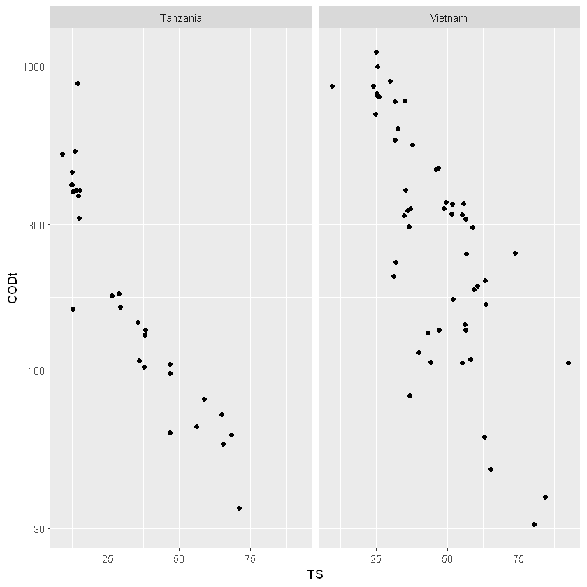

```r
# Update our aesthetics and add a facet
ggplot(metadata) +
    aes(x = TS, y = CODt) +
    geom_point() +
    scale_y_log10() +
    facet_grid(~Country)
```

### 1.2.0.11 Plots can be coloured using continuous variables

I could now add information from another variable as a colour in this plot. Note that if a variable is continuous instead of discrete, the colour will be a gradient.

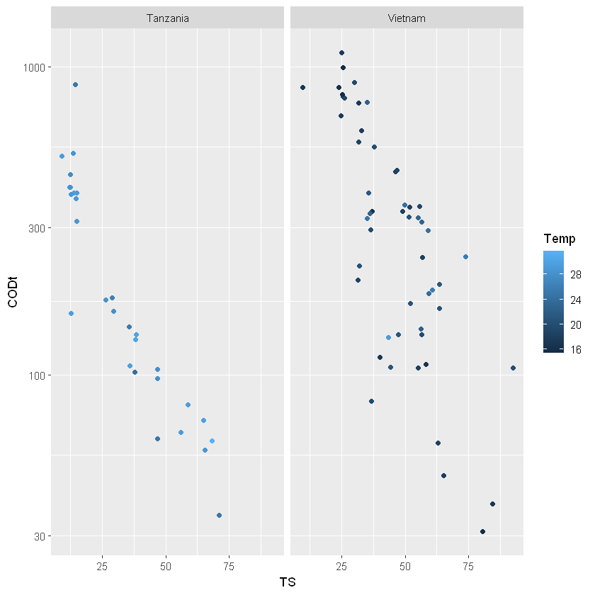

```r
ggplot(metadata) +
    aes(x = TS, y = CODt, colour = Temp) +
    geom_point() +
    scale_y_log10() +
    facet_grid(~Country)
```

### 1.2.0.12 Discriminate your variables by shape in the `aes()` parameters

If we really wanted to we could add another variable to the plot by changing the shape attribute. Let's change `Country` to having 2 shapes and facet by the `Depth` of the latrine instead.

Note that shape can only be used for discrete values.

A quick reference key for shapes can be found in the 'Cookbook for R' (http://www.cookbook-r.com/Graphs/Shapes_and_line_types/).

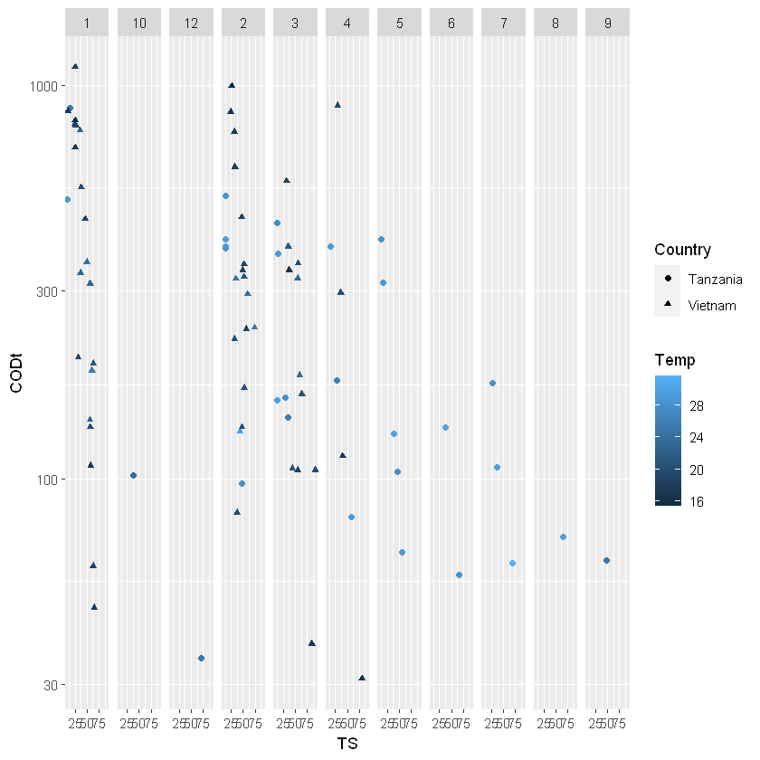

```r
# Change our point shape by Country and facet by Depth
ggplot(metadata) +
    aes(x = TS, y = CODt, colour = Temp, shape = Country) +
    geom_point() +
    scale_y_log10() +
    facet_grid(~Depth)
```

### 1.2.0.13 There are numerous ways to specify `facet_*()`

Note that up until now we've been using `facet_grid(~variable)` to split our data by variable. This annotation causes the grids to be distributed horizontally. Other ways to facet by a *single* variable are:

- `facet_grid(variable~.)` will distribute your grids vertically
- `facet_wrap(~variable)` will return a symmetrical matrix of plots based on levels in your variable.

We can now note that only Tanzania had sampling greater than 4cm of depth. There are single latrines for 4 samples. There was no latrine at a depth of 11cm. Lack of replication and a bias towards Tanzania for the higher depths is something we should keep in mind while looking at this data. Depending on the question we are trying to answer, we may want to remove some of these data.

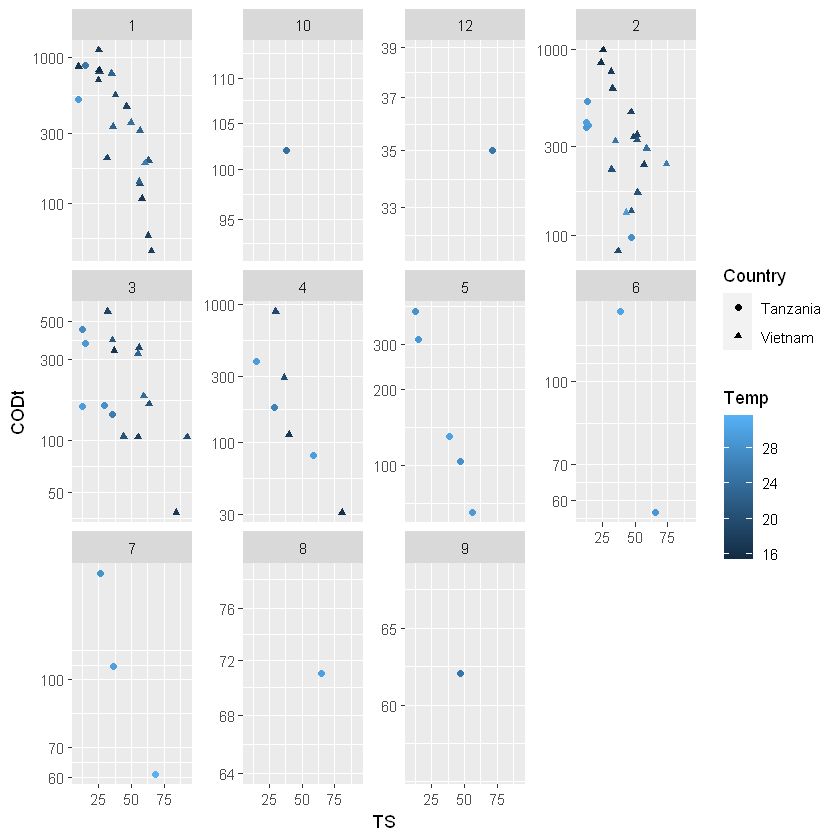

```r
# Use facet_wrap to rescale our y-axis individually
ggplot(metadata) +
    aes(x = TS, y = CODt, colour = Temp, shape = Country) +
    geom_point() +
    scale_y_log10() +
    facet_wrap(~Depth, scale = "free_y")
```

### 1.2.0.13b What issue do we encounter when faceting by "Depth"?

Have you noticed something strange about the past two versions of our graph? When faceting by "Depth", how are our groups being ordered? Why?

```r
# Let's remind ourselves of the metadata structure
glimpse(metadata)

# and fix what might be wrong
metadata$Depth = as.numeric(metadata$Depth)

glimpse(metadata)
```

```
Rows: 81
Columns: 7
$ Country        <fct> Tanzania, Tanzania, Tanzania, Tanzania, Tanzania, Ta...
$ Latrine_Number <chr> "2", "2", "2", "2", "2", "2", "2", "2", "3", "3", "3...
$ Depth          <chr> "1", "10", "12", "2", "3", "6", "7", "9", "2", "3", ...
$ pH             <dbl> 7.82, 9.08, 8.84, 6.49, 6.46, 7.69, 7.48, 7.60, 7.55...
$ Temp           <dbl> 25.1, 24.2, 25.1, 29.6, 27.9, 28.7, 29.8, 25.0, 28.8...
$ TS             <dbl> 14.53, 37.76, 71.11, 13.91, 29.45, 65.52, 36.03, 46....
$ CODt           <dbl> 874, 102, 35, 389, 161, 57, 107, 62, 384, 372, 315, ...
Rows: 81
Columns: 7
$ Country        <fct> Tanzania, Tanzania, Tanzania, Tanzania, Tanzania, Ta...
$ Latrine_Number <chr> "2", "2", "2", "2", "2", "2", "2", "2", "3", "3", "3...
$ Depth          <dbl> 1, 10, 12, 2, 3, 6, 7, 9, 2, 3, 5, 3, 4, 5, 6, 7, 2,...
$ pH             <dbl> 7.82, 9.08, 8.84, 6.49, 6.46, 7.69, 7.48, 7.60, 7.55...
$ Temp           <dbl> 25.1, 24.2, 25.1, 29.6, 27.9, 28.7, 29.8, 25.0, 28.8...
$ TS             <dbl> 14.53, 37.76, 71.11, 13.91, 29.45, 65.52, 36.03, 46....
$ CODt           <dbl> 874, 102, 35, 389, 161, 57, 107, 62, 384, 372, 315, ...
```

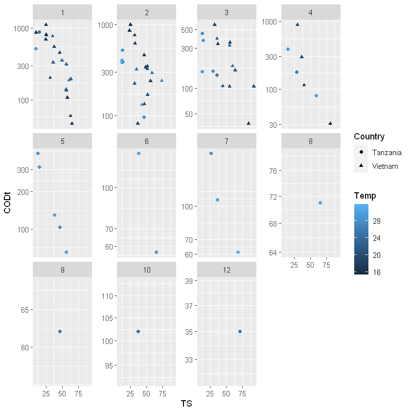

```r
# Plot our data with the updated metadata object
ggplot(metadata) +
    aes(x = TS, y = CODt, colour = Temp, shape = Country) +
    geom_point() +
    scale_y_log10() +
    facet_wrap(~Depth, scales = "free_y")
```

## 1.3.0 Add regression lines using statistical transformations

You can also add **statistical transformations** to your plots. Again, take a look at stat_ then `Tab` to see the list of options. In this case let's separately fit a linear regression line to CODt vs TS for each country. The grey area around the line is the confidence interval (default=0.95) and can be removed with the additional call to stat_smooth of `se = FALSE`.

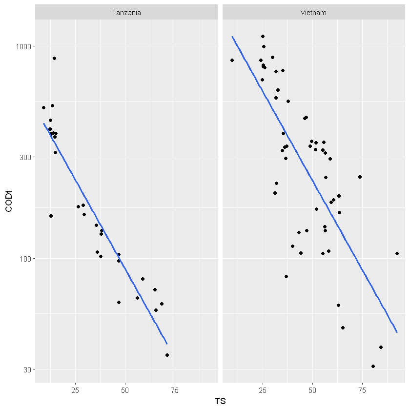

```r
# Add our regression line with stat_smooth
ggplot(metadata) +
    aes(x=TS, y=CODt) +
    geom_point() +
    scale_y_log10() +
    facet_grid(~Country) +
    stat_smooth(method = lm, se=FALSE)
```

## 1.3.1 Play around with regression models and use the `alpha` parameter to de-emphasize data

A linear model is not always the best fit. The method of calculating the smoothing function can be changed to other provided functions (such as loess -short for local regression, used below) or can be a custom formula. We'll talk more about making our own models in Lecture 06! Note that I changed the confidence interval by modifying `level=0.8`.

`geoms` can be made more transparent with the `alpha` parameter, which is set to 0.3 in the following code so that the emphasis is on the regression line rather than the points.

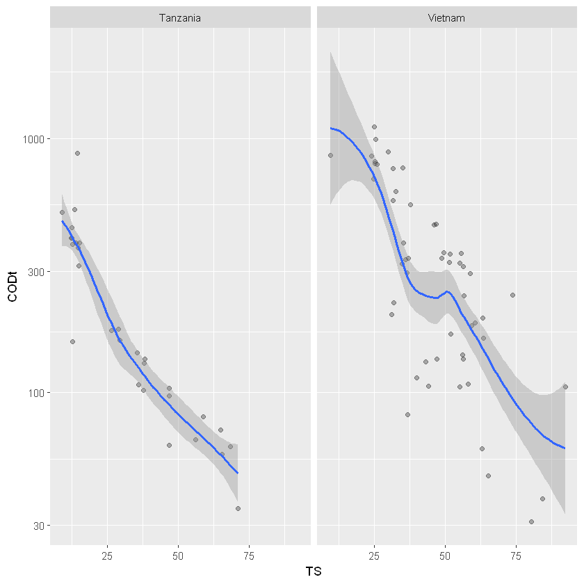

```r
# Set the alpha on geom_point and change our regression method
ggplot(metadata) +
    aes(x=TS, y=CODt) +
    geom_point(alpha = 0.3) +
    scale_y_log10() +
    facet_grid(~Country) +
    stat_smooth(method = loess, level = 0.8)
       #Loess: locally estimated scatter plot smoothing. Non-parametric approach that fits multiple regressions in local neighborhood
```

## 2.0.0 Exploring different types of plots

Let's take a look at the latrines dataset by loading it up first

```r
# Load up the taxa_pitlatrine.csv dataset
latrines <- read_csv("data/taxa_pitlatrine.csv", col_types = 'ccici')
print("latrines structure")
str(latrines)
```

```
[1] "latrines structure"
tibble [4,212 x 5] (S3: spec_tbl_df/tbl_df/tbl/data.frame)
 $ Taxa          : chr [1:4212] "Acidobacteria_Gp1" "Acidobacteria_Gp10" "Acidobacteria_Gp14" "Acidobacteria_Gp16" ...
 $ Country       : chr [1:4212] "Tanzania" "Tanzania" "Tanzania" "Tanzania" ...
 $ Latrine_Number: int [1:4212] 2 2 2 2 2 2 2 2 2 2 ...
 $ Depth         : chr [1:4212] "1" "1" "1" "1" ...
 $ OTUs          : int [1:4212] 0 0 0 0 0 0 0 0 0 0 ...
 - attr(*, "spec")=
  .. cols(
  ..   Taxa = col_character(),
  ..   Country = col_character(),
  ..   Latrine_Number = col_integer(),
  ..   Depth = col_character(),
  ..   OTUs = col_integer()
  .. )
```

## 2.1.0 View the theoretical distibution of your data with density plots

What is the distribution of OTUs by *sample site* in each country? We can quickly visualize this property by making a density plot for OTUs by Country. I have set alpha (transparency) to 0.3 so that we can see both countries on our plot.

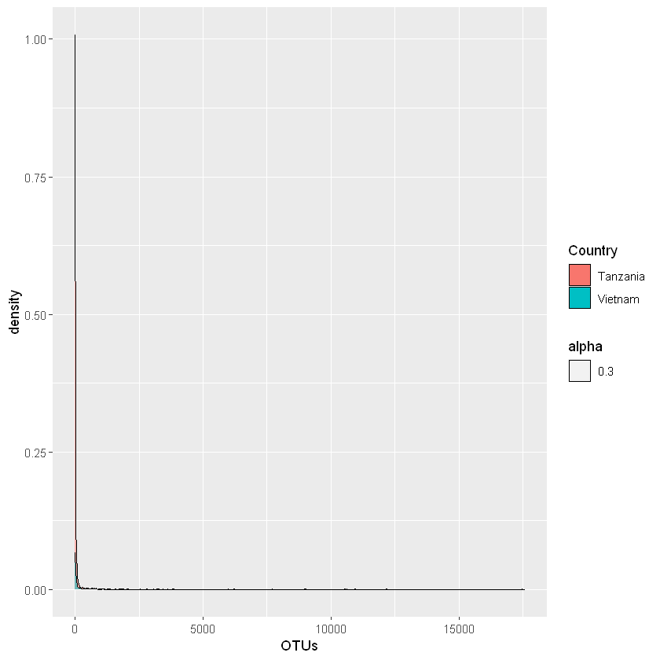

```r
ggplot(latrines) +
    aes(x=OTUs, fill=Country, alpha=0.3) +
    geom_density()
```

## 2.1.1 Set the limits of your axes with `xlim()`

The first thing to notice is that everything is clumped at 0. This is because we have not filtered our data frame to remove all observations where OTUs are zero. The other thing to notice is that there is a long tail where there will only be a few observations. It will be necessary to change the x-axis to see our data. This is done by setting 'limits' (lower and upper boundaries) on the x-axis with `xlim()`. Note that R gives us a warning that we are not viewing 158 of our 4212 rows.

Let's do the following:

1. Filter our data to have at least 2 OTUs.
2. Set upper and lower boundaries with `xlim()`
3. Add a `geom_rug` so that we can see where each value falls along the distribution

```
Warning message:
"Removed 158 rows containing non-finite values (stat_density)."
```

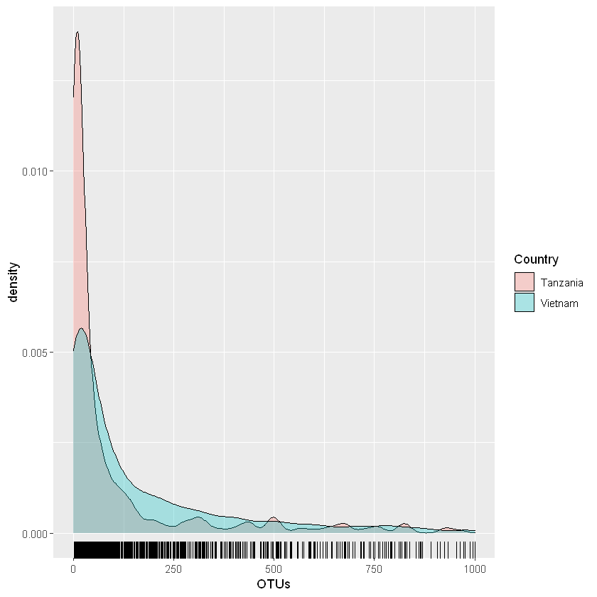

```r
latrines %>% filter(OTUs >=2) %>% # call data and filter "on the fly"
ggplot(.) +
    aes(x=OTUs, fill=Country) +
    geom_density(alpha = 0.3) +
    geom_rug() +
    xlim(0, 1000)

    # geom_rug adds lines on the desired axis to indicate data points.
    # Rug plots display individual cases so are best used with smaller datasets.
```

## 2.2.0 Histograms can similarly visualize our distribution

Unlike density plots, histograms count the number of observations you have in each 'bin' that you specify. So with proper parameters you can recreate a similar shape to your density plots using only the observed data.

```
Warning message:
"Removed 158 rows containing non-finite values (stat_bin)."
Warning message:
"Removed 4 rows containing missing values (geom_bar)."
```

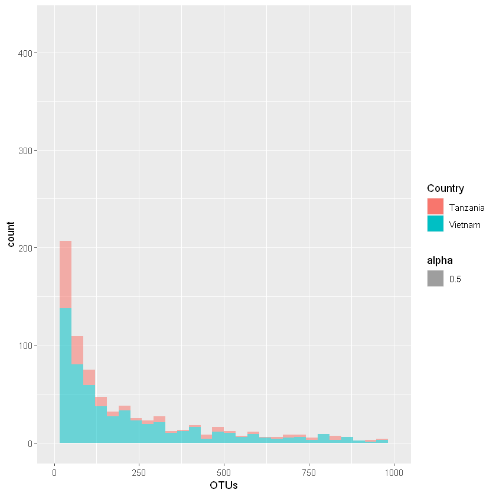

```r
# Let's make a filtered_latrines variable to work with
filtered_latrines <- latrines %>% filter(OTUs >=2)

# Use a geom_histogram instead of geom_density
ggplot(filtered_latrines) +
    aes(x=OTUs, fill=Country, alpha=0.5) +
    geom_histogram() +
    xlim(0, 1000)
```

## 2.2.1 Use the `position` parameter to alter how data is stacked

Instead of having the countries information stacked, we may want to see the data side by side. This can be done with the parameter `position` set to 'dodge'. Let's do the following:

1. Set a larger bin width
2. Dodge our data
3. Add a y-axis limit with `ylim()`
4. Add a `geom_rug()`

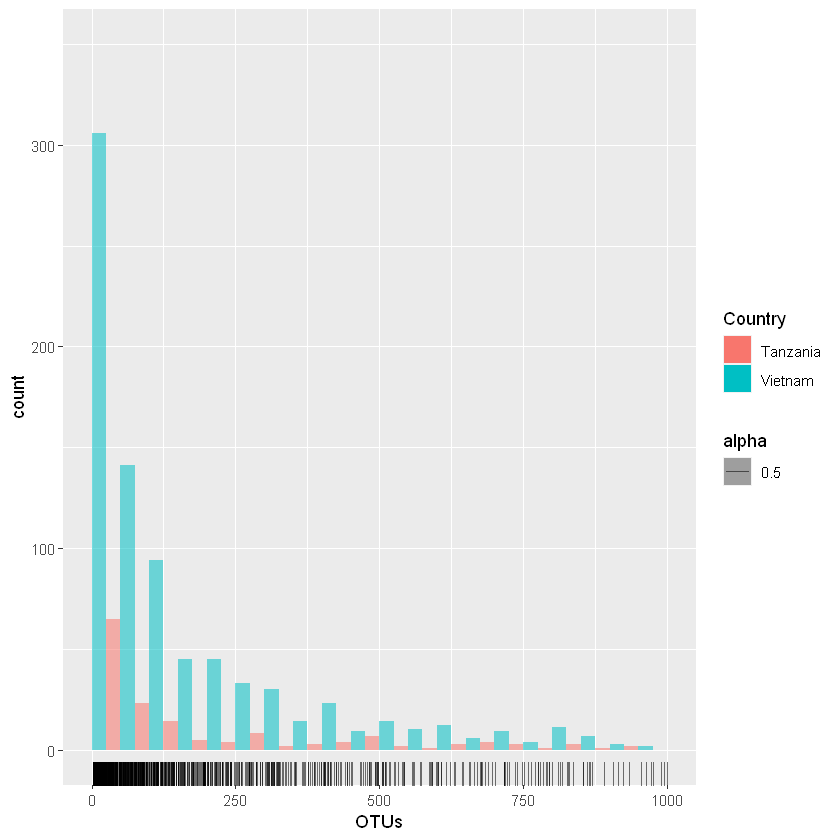

```r
# Update with dodgine the data, ylim and geom_rug
ggplot(filtered_latrines) +
    aes(x=OTUs, fill=Country, alpha=0.5) +
    geom_histogram(binwidth = 50, position = "dodge") +
    xlim(0,1000) +
    ylim(0, 350) +
    geom_rug()
```

## 2.2.2 Barplots stack our categorical data for us.

Can we create a bar plot of OTUs per country? With `geom_bar()` and the proper `aes()` we can fill in colour along the bar to represent specific Taxa. Note that by *default* `geom_bar()` uses `stat="bin"` which will count the number of occurences within each group (x).

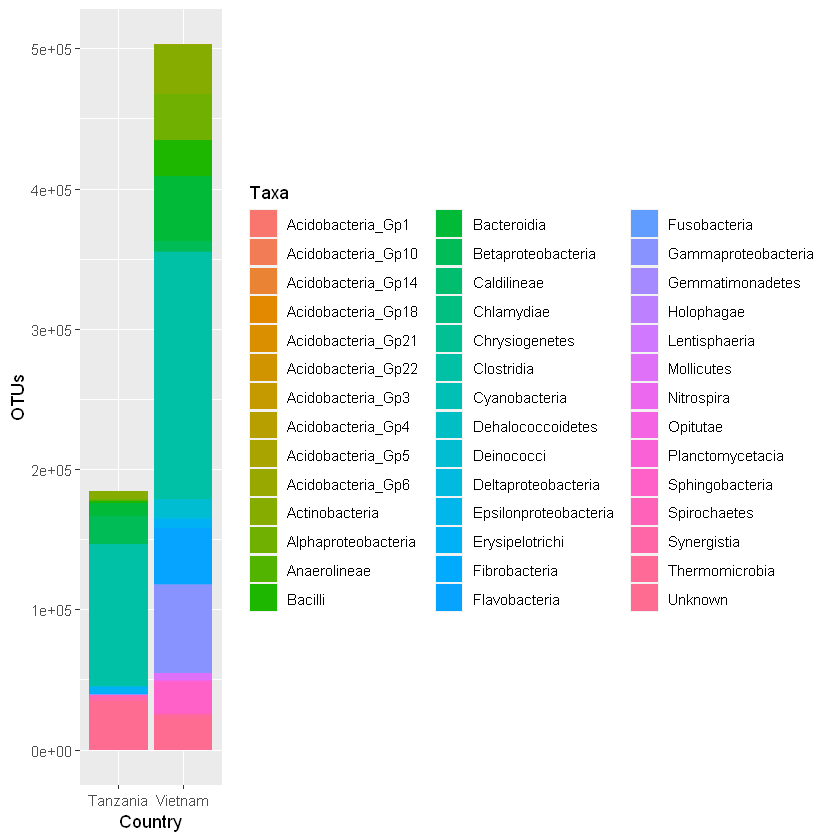

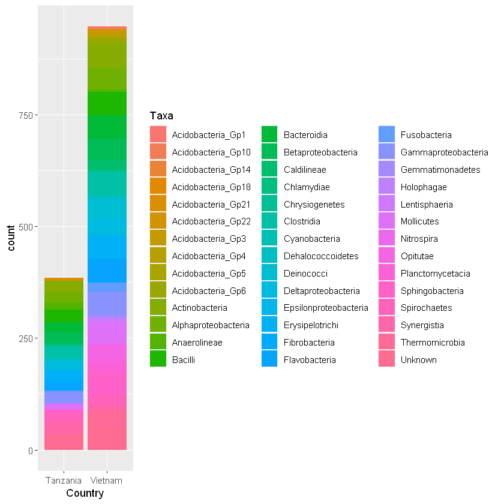

```r
# Make a bar graph based on OTUs and fill by taxa
ggplot(filtered_latrines) +
    aes(x = Country, y = OTUs, fill = Taxa) +
    geom_bar(stat="identity")

# What happens if we don't specify an "identity" and y-axis value?
ggplot(filtered_latrines) +
    aes(x = Country, fill = Taxa) +
    geom_bar()
```

## 2.2.3 Controlling the order of categorical variables in your legend with `fct_reorder2()`

In the legend for the bar plot our factor levels for Taxa are in *alphabetical order*. However, an ordering that might be more useful would be an order that matches our data, for example, Taxa in descending order of OTU abundance.

To do this, we can use the `forcats` package (included in `tidyverse` and already loaded). `fct_reorder2()` takes the factor we want ordered (Taxa) and associates the highest x values (Country) with their y values (OTUs) ordering them in descending order. This is most relevent when working with line graphs but works for our bar graphs too.

We will talk about customizing plots later in this lesson, but the last line of code is one way to remove the legend title (by making the `legend.title` 'blank').

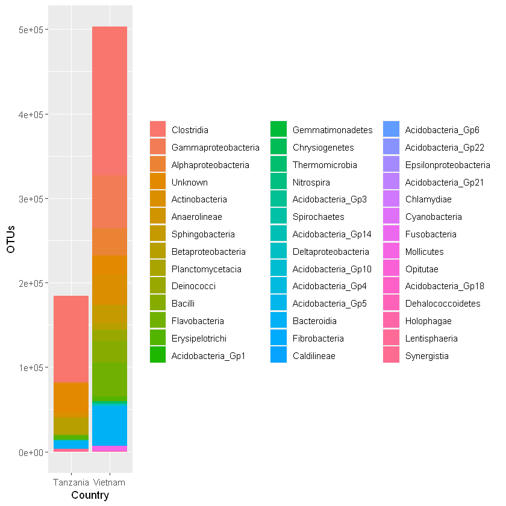

```r
ggplot(filtered_latrines) +
    aes(x = Country, y = OTUs, fill = fct_reorder2(Taxa, Country, OTUs)) + # reorder the levels in Taxa by Country and OTUs
    geom_bar(stat = "identity") +
    theme(legend.title = element_blank()) # remove legend
```

## 2.2.4 You can dodge your barplots too!

You can alternate between 'stacked' or 'dodged' (as we did with the histogram) for whether your bars are on top or next to each other when splitting by a factor or categorical variable.

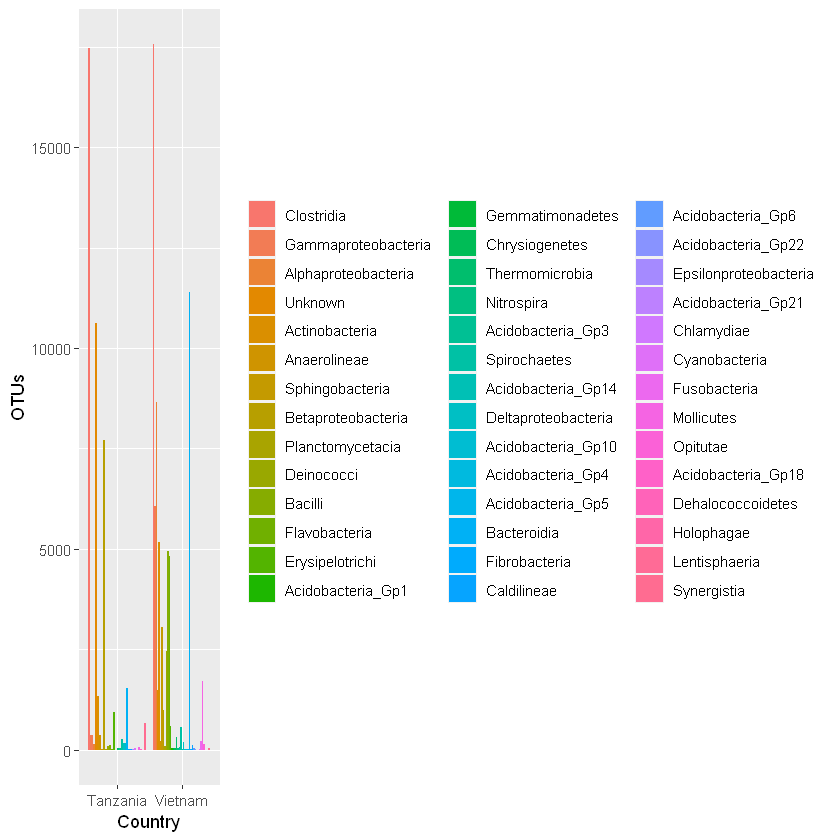

```r
# Update our graph to dodge the bars instead of stacking
ggplot(filtered_latrines) +
    aes(x = Country, y = OTUs, fill = fct_reorder2(Taxa, Country, OTUs)) +
    geom_bar(stat = "identity", position = "dodge") +
    theme(legend.title = element_blank())
```

## 2.2.5. Flip your data to display horizontally with `coord_flip()`

Our data looks quite squished when displaying the bars vertically. You can have your bars horizontal instead of vertical by using the `coord_flip()` layer.

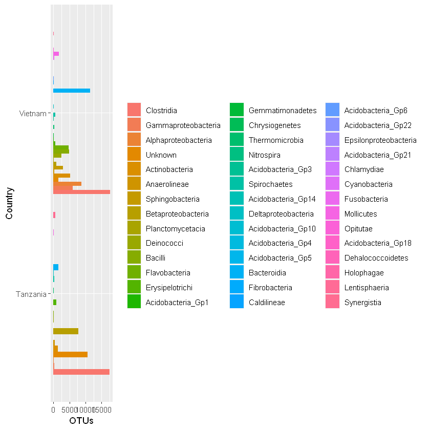

```r
# Let's flip this graph
ggplot(filtered_latrines) +
    aes(x=Country, y=OTUs, fill=fct_reorder2(Taxa, Country, OTUs)) +
    geom_bar(stat = "identity", position = "dodge") +
    theme(legend.title = element_blank()) +
    coord_flip()
```

## 2.2.6 Updating the image size in Jupyter through `repr`

You may have noticed that when your legends are quite large, you lose some real estate on your actual graph. This is due to how we output the graphs both when saving and in displaying. In Jupyter, the standard output dimension is a 7x7inch graph.

When displaying your graphs in Jupyter you can update `options` through the `repr` library to widen or lengthen graphs as you create them with big legends or multiple facets. We'll talk about the process of saving them soon as well. First, let's fix our last graph.

```r
# Load the repr package to change width
library(repr)

# Note that the standard display size is a 7x7 inch space. let's double the width
options(repr.plot.width=14, repr.plot.height=7)
```

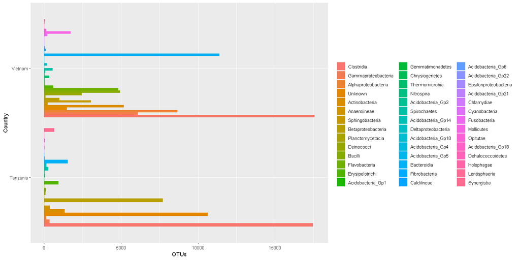

```r
# Let's take a look at our plot again
ggplot(filtered_latrines) +
    aes(x=Country, y=OTUs, fill=fct_reorder2(Taxa, Country, OTUs)) +
    geom_bar(stat = "identity", position = "dodge") +
    theme(legend.title = element_blank()) +
    coord_flip()
```

## 2.3.0 Boxplots provide visual summary statistics of your data

Boxplots are a great way to visualize summary statistics for your data. As a reminder, the thick line in the center of the box is the **median**. The upper and lower ends of the box are the first and third **quartiles** (or 25th and 75th percentiles) of your data. The whiskers extend to the largest value no further than 1.5*IQR (inter-quartile range - the distance between the first and third quartiles). Data beyond these whiskers are considered outliers and plotted as individual points. This is a quick way to see how comparable your samples or variables are.

We are going to use boxplots to see the distribution of OTUs per Taxa across all samples.

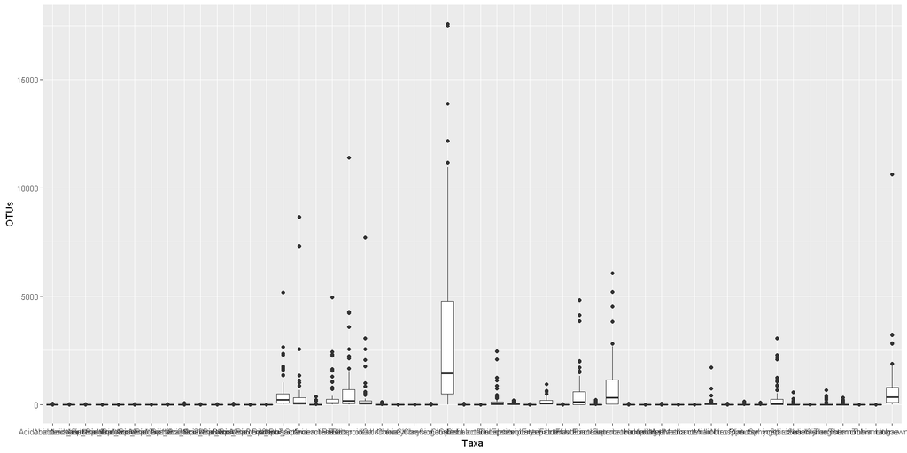

```r
# Let's make a basic boxplot with our original latrines data
ggplot(latrines) +
    aes(x = Taxa, y = OTUs) +
    geom_boxplot()
```

## 2.3.1 Rotate axis text by updating `theme()` and `angle`

So we can immediately see there are some issues with the plot. Text along the x-axis is overlapping and illegible. Let's fix the text on the x-axis by rotating it 90 degrees. To accomplish this we will use the `theme()` layer.

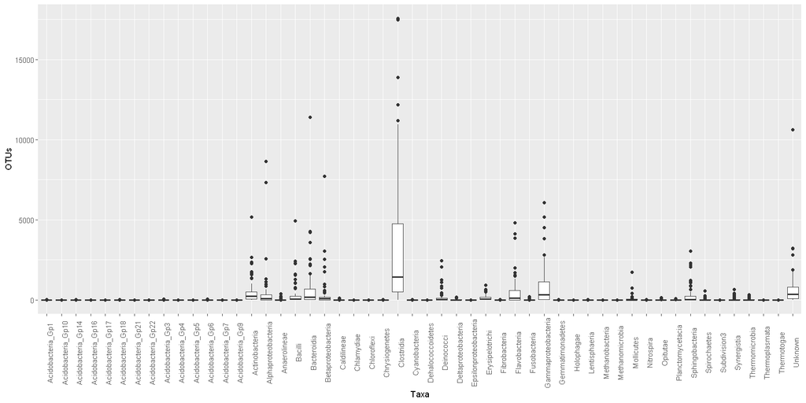

```r
# Access the theme of the plot and update the text angle
ggplot(latrines) +
    aes(x = Taxa, y = OTUs) +
    geom_boxplot() +
    theme(axis.text.x = element_text(angle=90))
```